# Reproducible Research: Peer Assessment 1

### Loading and preprocessing the data

Unzip the data and read it into R.

```r
unzip("activity.zip")
activity <- read.csv("activity.csv")
```

Process the data to make it suitable for further analysis. Parse the date string as a Date object.

```r
activity$date <- as.Date(activity$date, format="%Y-%m-%d")
```

### What is mean total number of steps taken per day?

Ignore the missing values in the dataset.

```r
activityNoNa <- activity[!is.na(activity$steps),]
```

Summarize the data to get steps per day.

```r
stepsPerDay <- rowsum(activityNoNa, activityNoNa$date)
stepsPerDay$date <- as.Date(row.names(stepsPerDay), format="%Y-%m-%d")
```

Plot histogram to see how the steps per day have evolved over time.

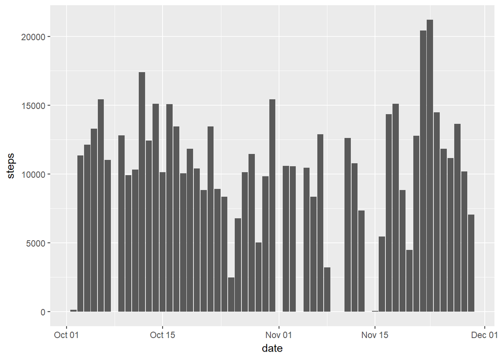

```r
library(ggplot2)
stepsPerDayPlot <- ggplot(stepsPerDay, aes(x = date, y = steps))
stepsPerDayPlot <- stepsPerDayPlot + geom_bar(stat = "identity")
stepsPerDayPlot
```

As we can see in the plot, the number of steps is quite differring. There are various days on which no steps where recorded at all. A peak can be found around the end of November.

When we have a look at the **mean** and **median** total number of steps taken per day:

```r
mean(stepsPerDay$steps)
```

```
## [1] 10766.19
```

```r
median(stepsPerDay$steps)
```

```
## [1] 10765
```

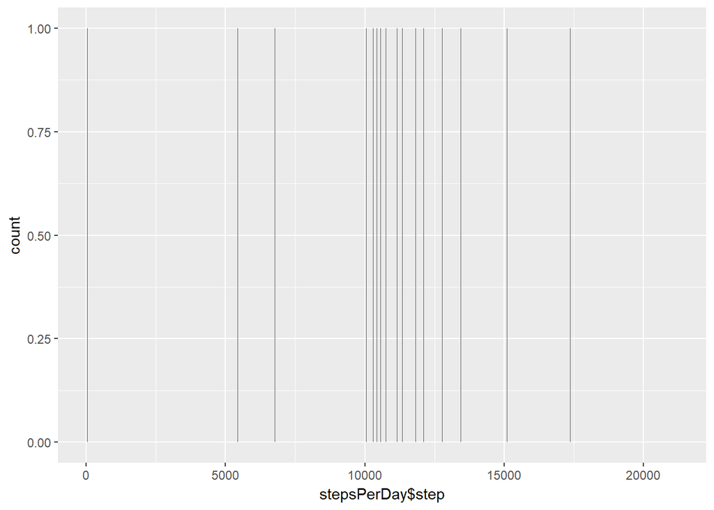

```r
qplot(stepsPerDay$step, geom="bar")
```

### What is the average daily activity pattern?

To answer this question we first make a time series plot of the 5-minute interval (x-axis) and the average number of steps taken, averaged across all days (y-axis):

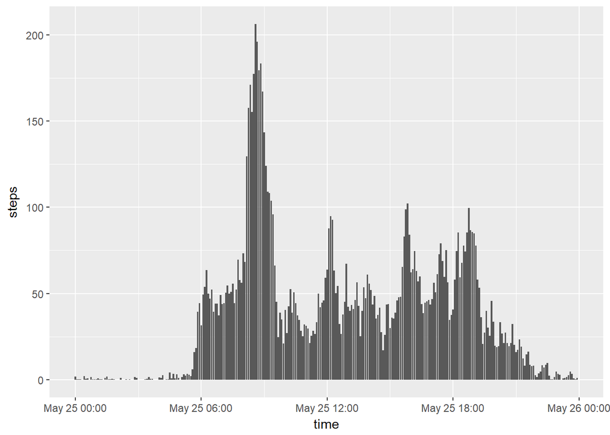

```r
stepsPerInterval <- aggregate(activityNoNa, list(interval = activityNoNa$interval), mean)
stepsPerInterval$time <- formatC(stepsPerInterval$interval, width = 4, format = "d", flag = "0")
stepsPerInterval$time <- as.POSIXct(stepsPerInterval$time, format="%H%M")
stepsPerIntervalPlot <- ggplot(stepsPerInterval, aes(x = time, y = steps)) +
   geom_bar(stat = "identity")
stepsPerIntervalPlot
```

We can get the 5-minute interval, that on average across all the days in the dataset, contains the maximum number of steps as follows:

```r
mostStepsOfTheDay <- stepsPerInterval[which.max(stepsPerInterval$steps),]$interval
```

That is, this person, on average takes the most steps at 835.

### Imputing missing values

Note that there are a number of days/intervals where there are missing values (coded as `NA`). The presence of missing days may introduce bias into some calculations or summaries of the data.

Therefore we calculate and report the total number of missing values in the dataset (i.e. the total number of rows with `NA`s):

```r
sum(is.na(activity$steps))
```

```
## [1] 2304
```

Next, we devise a strategy for filling in all of the missing values in the dataset:

As we have already calculated the mean value for each interval, we will reuse these values to fill in the gaps.

Now we have chosen a strategy, we create a new dataset that is equal to the original dataset but with the missing data filled in.

```r
activityImputed <- NULL
activityMissing <- activity[is.na(activity$steps), ]

for(i in 1:nrow(activityMissing)) {
    row <- activityMissing[i,]
    row$steps <- stepsPerInterval[stepsPerInterval$interval == row$interval, ]$steps[1]
    activityImputed <<- rbind(row, activityImputed)
}

activityImputed <- rbind(activityImputed, activity[!is.na(activity$steps), ])
```

We reuse our code from before to ake a histogram of the total number of steps taken each day.

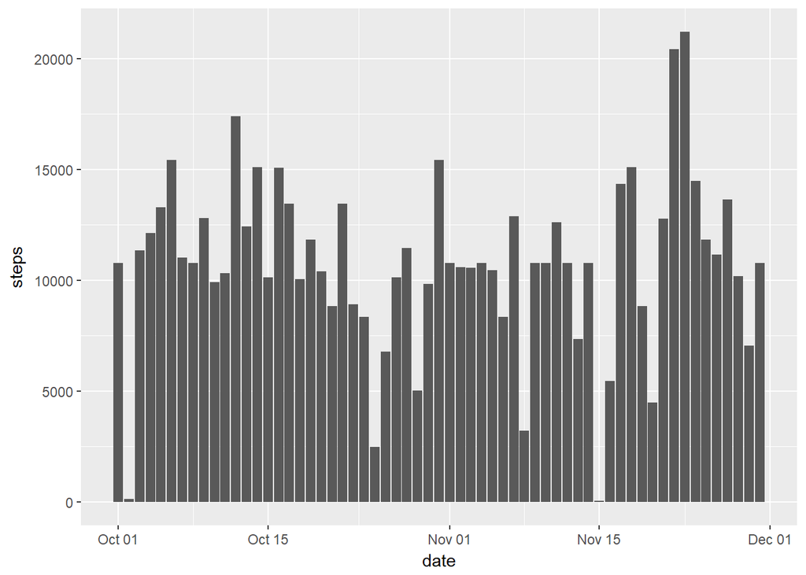

```r
stepsPerDayImp <- rowsum(activityImputed, activityImputed$date)
stepsPerDayImp$date <- as.Date(row.names(stepsPerDayImp), format="%Y-%m-%d")

stepsPerDayImpPlot <- ggplot(stepsPerDayImp, aes(x = date, y = steps))
stepsPerDayImpPlot <- stepsPerDayImpPlot + geom_bar(stat = "identity")
stepsPerDayImpPlot
```

Next, we calculate and report the **mean** and **median** total number of steps taken per day.

```r
mean(stepsPerDayImp$steps)
```

```
## [1] 10766.19
```

```r
median(stepsPerDayImp$steps)
```

```
## [1] 10766.19
```

As we can see, this hardly changes the values which we calculated before. The most ‘striking’ difference is that now the median and the average steps per day are exactly the same.

### Are there differences in activity patterns between weekdays and weekends?

We use the dataset with the filled-in missing values for this part. First we create a new factor variable in the dataset with two levels – “weekday” and “weekend” indicating whether a given date is a weekday or weekend day.

```r
weekends <- activityImputed$date
weekends <- weekdays(weekends) %in% c("Saturday", "Sunday")
activityImputed <- transform(activityImputed, week = ifelse(weekends ,'weekend', 'weekday'))
activityImputed$week <- as.factor(activityImputed$week)
```

Finally, we make a panel plot containing a time series plot of the 5-minute interval (x-axis) and the average number of steps taken, averaged across all weekday days or weekend days (y-axis).

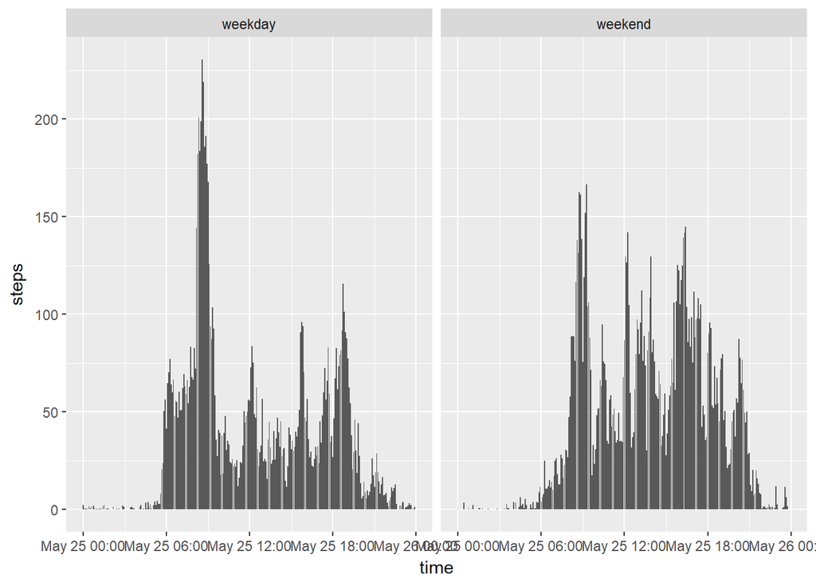

```r
stepsPerIntervalByWeek <-
  aggregate(activityImputed, list(interval = activityImputed$interval, week = activityImputed$week), mean)
stepsPerIntervalByWeek$time <- formatC(stepsPerIntervalByWeek$interval, width = 4, format = "d", flag = "0")
stepsPerIntervalByWeek$time <- as.POSIXct(stepsPerIntervalByWeek$time, format="%H%M")

g <- ggplot(stepsPerIntervalByWeek, aes(x = time, y = steps))
g <- g + geom_bar(stat = "identity")
g <- g + facet_wrap(~week, ncol=2)
g
```